# Human Activity Recognition: A Practical Case

Emilio Delgado

Saturday, June 20, 2015

## 1. Introduction

Human Activity Recognition - **HAR** - has emerged as a key research area in the last years. Using devices such as Jawbone Up, Nike FuelBand, and Fitbit it is now possible to collect a large amount of data about personal activity relatively inexpensively. This data may be used to build models and make predictions about the type of activity being performed, how much of this activity, and, ultimately, how well this activity is being performed.

This study is based on this reference: Velloso, E.; Bulling, A.; Gellersen, H.; Ugulino, W.; Fuks, H. *Qualitative Activity Recognition of Weight Lifting Exercises*. Proceedings of 4th International Conference in Cooperation with SIGCHI (Augmented Human ’13) . Stuttgart, Germany: ACM SIGCHI, 2013.

Read more: http://groupware.les.inf.puc-rio.br/har#ixzz3ddIN4TAv

## 2. Data Preparation

The training data was dowloaded from : https://d396qusza40orc.cloudfront.net/predmachlearn/pml-training.csv. It was read into a training data frame using the following code:

```r
training <- read.csv("pml-training.csv",as.is=TRUE,na.strings=c("NA","","#DIV/0!"),numerals="allow.loss")
dim(training)
```

```
## [1] 19622   160
```

This data contains observations of the accelerometers readings at regular intervals. An sliding window is then used to compute main statistics (mean, variance, etc). Each observation is tagged with the subject’s name, the timestamp and the window number. When a window is completed and a new one is started, this event is also tagged (by setting the variable new_window=“yes”), and the completed window statistics are included in the corresponding row. All these tags are located in the first seven columns of the data set:

```r
head(training[,1:7])
```

```
##   X user_name raw_timestamp_part_1 raw_timestamp_part_2   cvtd_timestamp new_window num_window
## 1 1  carlitos           1323084231               788290 05/12/2011 11:23         no         11
## 2 2  carlitos           1323084231               808298 05/12/2011 11:23         no         11
## 3 3  carlitos           1323084231               820366 05/12/2011 11:23         no         11
## 4 4  carlitos           1323084232               120339 05/12/2011 11:23         no         12
## 5 5  carlitos           1323084232               196328 05/12/2011 11:23         no         12
## 6 6  carlitos           1323084232               304277 05/12/2011 11:23         no         12
```

As the purpose of the model is to predict only from actual, real-time sensor readings, we must not include in the training all these tags. We will also drop the columns that contain statistics, as the data they contain are not available in the testing data set. We can confirm this point by looking at the test data we are requested to use. This data is downloaded from : https://d396qusza40orc.cloudfront.net/predmachlearn/pml-testing.csv, and read into a data frame using the same code as the training data:

```r
testing <- read.csv("pml-testing.csv",as.is=TRUE,na.strings=c("NA","","#DIV/0!"),numerals="allow.loss")
dim (testing)
```

```
## [1]  20 160
```

```r
nrow(testing[testing$new_column=="yes",])
```

```
## [1] 0
```

The variable we want to predict is coded in the column **classe** by means of five letters. According to the article cited, class A corresponds to the specified execution of the exercise, while the other 4 classes correspond to common mistakes.

```r
unique(training$classe)
```

```
## [1] "A" "B" "C" "D" "E"
```

We therefore will drop the mentioned rows and columns from the training data set. We will also convert the column classe into a factor so we can build a classification model:

```r
training <- training[training$new_window=="no",]
training <- training[,c(-1,-2,-3,-4,-5,-6,-7)]
training <- training[, colSums(is.na(training)) == 0]
training$classe <- as.factor(training$classe)
```

where the third line clears all the columns with NAs, which eliminates indirectly all the columns corresponding to window statistics (that are only available at the begining of each window, i.e. when new_window==“yes”)

## 3. Building a Model

We first take a look at the training data distribution among classes:

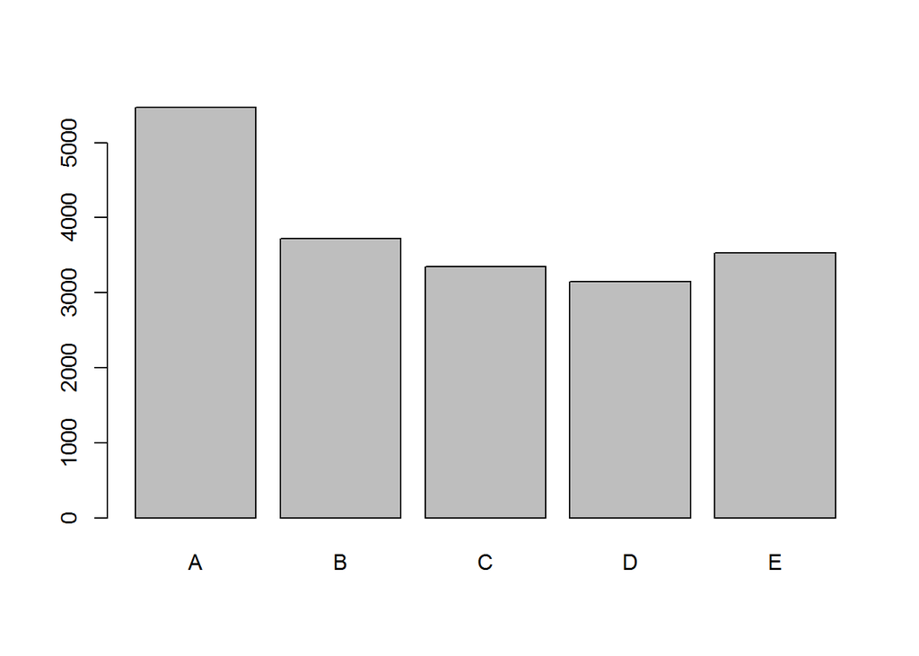

```r
barplot(table(training$classe))
```

We will use cross validation on the training data set in order to estimate the accuracy of the model. For that purpose we create a data partition with p=0.6.

```r
library(caret)
intrain1 <- createDataPartition(y=training$classe,p=0.6,list=FALSE)
train1 <- training[intrain1,]
test1 <- training[-intrain1,]
```

As stated in the introduction, our aim is to build a prediction model that predicts the class A,B,C,D,E from the sensor readings. We are aiming at an observed accuracy of 19/20 = 0.95. We can start our analysis with a decission tree classification model:

```r
library(rpart)
model <- rpart(classe~.,data=train1)
```

We can plot the resulting decission tree using the following code:

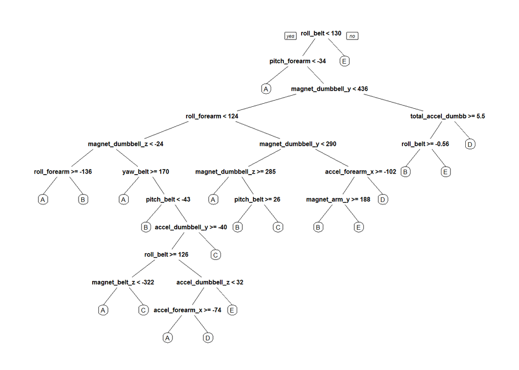

```r
library(rpart.plot)
prp(model)
```

In this plot we can easily interpret the model and see what are main variables involved in the classification. We will next check the accuracy of this model using cross validation with the remaining part of the training data:

```r
model1 <- rpart(classe~.,data=train1)
predictions <- predict(model1,newdata=test1,type="class")
cmatrix <- confusionMatrix(predictions,test1$classe)
cmatrix
```

```
## Confusion Matrix and Statistics
##
##           Reference
## Prediction    A    B    C    D    E
##          A 1992  224   19   83   29
##          B   96  948  137  122  282
##          C   65  153 1103  187  182
##          D   23  128   81  801   86
##          E   12   34    0   65  832
##
## Overall Statistics
##
##                Accuracy : 0.7387
##                  95% CI : (0.7287, 0.7485)
##     No Information Rate : 0.2847
##     P-Value [Acc > NIR] : < 2.2e-16
##
##                   Kappa : 0.6685
##  Mcnemar's Test P-Value : < 2.2e-16
##
## Statistics by Class:
##
##                      Class: A Class: B Class: C Class: D Class: E
## Sensitivity            0.9104   0.6375   0.8231   0.6367   0.5897
## Specificity            0.9354   0.8972   0.9075   0.9505   0.9823
## Pos Pred Value         0.8487   0.5981   0.6527   0.7158   0.8823
## Neg Pred Value         0.9633   0.9116   0.9605   0.9304   0.9141
## Prevalence             0.2847   0.1935   0.1744   0.1637   0.1836
## Detection Rate         0.2592   0.1234   0.1435   0.1042   0.1083
## Detection Prevalence   0.3054   0.2063   0.2199   0.1456   0.1227
## Balanced Accuracy      0.9229   0.7674   0.8653   0.7936   0.7860
```

The 0.7 accuracy factor obtained is too low for our purposes, so we need to improve the training method. The article cited in the introduction already mentions that due to the inherent noise present in sensor readings, it is worth trying a *random forest* method. We therefore train our model with the following code:

```r
library(randomForest)
model2 <- randomForest(classe~.,data=train1)
predictions <- predict(model2,newdata=test1)
cmatrix <- confusionMatrix(predictions,test1$classe)
cmatrix
```

```
## Confusion Matrix and Statistics
##
##           Reference
## Prediction    A    B    C    D    E
##          A 2184    8    0    0    0
##          B    4 1475    7    0    0
##          C    0    4 1332   27    4
##          D    0    0    1 1231    4
##          E    0    0    0    0 1403
##
## Overall Statistics
##
##                Accuracy : 0.9923
##                  95% CI : (0.9901, 0.9941)
##     No Information Rate : 0.2847
##     P-Value [Acc > NIR] : < 2.2e-16
##
##                   Kappa : 0.9903
##  Mcnemar's Test P-Value : NA
##
## Statistics by Class:
##
##                      Class: A Class: B Class: C Class: D Class: E
## Sensitivity            0.9982   0.9919   0.9940   0.9785   0.9943
## Specificity            0.9985   0.9982   0.9945   0.9992   1.0000
## Pos Pred Value         0.9964   0.9926   0.9744   0.9960   1.0000
## Neg Pred Value         0.9993   0.9981   0.9987   0.9958   0.9987
## Prevalence             0.2847   0.1935   0.1744   0.1637   0.1836
## Detection Rate         0.2842   0.1920   0.1733   0.1602   0.1826
## Detection Prevalence   0.2853   0.1934   0.1779   0.1609   0.1826
## Balanced Accuracy      0.9984   0.9951   0.9943   0.9889   0.9972
```

We produce our predictions with the following code:

```r
testing <- read.csv("pml-testing.csv",as.is=TRUE,na.strings=c("NA","","#DIV/0!"),numerals="allow.loss")
answers <- predict(model,newdata=testing)
```